# ejercicio-analisis-textual

Romina De León

21/7/2021

## Comenzando con análisis textual en R Studio

Durante esta ejercitación utilizaras lo visto en las unidades previas. El corpus que he dejado en la carpeta del campus, está compuesto por discursos del presidente A. Fernández y Decretos de Necesidad de Urgencia (DNU) dictados por el Poder Ejecutivo de la Argentina. Estos se presentaron a la población del país desde el inicio del Distanciamiento Social, Preventivo y Obligatorio (DIASPO) el 13 de marzo, hasta el 30 de junio de 2020[^1].

El corpus fue denominado según el siguiente orden: `mes-día-dnu o disc` en formato de texto plano (`txt`). Asimismo, para este ejercicio se utilizarán los primeros cuatro archivos, `0313disc.txt`;`0316dnu.txt`; `0318dnu.txt` y `0320disc.txt`. Esto fue pensado así para poder iniciar pequeñas visualizaciones de esos archivos, donde se podrás observar comparaciones de días, para luego pasar a generalizar con los 47 textos del corpus.

**Primero paso**: deberás armar una carpeta, donde ubiques los archivos a utilizar, en mi ejemplo la denominé **discurso**. Esto es fundamental evitar problemas durante el ejercicio.

```r
getwd()

#Deben modificar su ubicación

setwd("discurso")
```

El paso a seguir es llamar a las librerías que se utilizaran:

```r
library("tidytext", "tidyverse")
```

Una vez instalados estos requerimientos, llamaras a la función `list.file` para corroborar que los archivos necesarios se encuentran en la carpeta donde estás trabajando.

```r
list.files('discurso')
```

Podrás observar que están los archivos que necesitaras.

En un segundo paso, conformaras una nueva **lista**, a la que puedes llamar `archivos`, cuyos elementos serán los textos planos dentro de la carpeta **discurso**, para ello, utilizaras, nuevamente, la función `list.files`, y le indicaras que tipo de archivo debe contener, **txt**, con la declaración `pattern`.

```r
archivos <- list.files(pattern = "\\.txt$")

# Recuerda estar trabajando en la carpeta donde se encuentran tus archivos, sino deberas incorporar un declaración que indique la ubicación, 'path ='.

archivos #corrobora que la lista está correcta
```

```
## [1] "0313disc.txt" "0316dnu.txt"  "0318dnu.txt"  "0320disc.txt"
```

```r
class(archivos) #podrás ver que se trata de una lista de caracteres
```

```
## [1] "character"
```

```r
length(archivos) #la función 'length' permite obtener el tamaño del objeto que se incluye dentro de los paréntesis
```

```
## [1] 4
```

Tercer paso, será para facilitar la visualización de cada texto en los siguientes pasos, por lo cual, se eliminará lo que no es necesario del nombre de cada archivo. Para ello, utilizaras la función `gsub`, de gran utilidad para limpieza de datos que está incluida por defecto en **R**. Los parámetros indicaran, según orden de escritura, que se eliminará (\\. será para indicar que se busca un **`.`** y no otro carácter según las reglas de expresión regular), que se agregará, las doble comillas vacías, y finalmente, con **perl**, para que se utilice de manera determinada las reglas de expresiones regulares[^3].

```r
textos_archivo <- gsub("\\.txt", "", archivos, perl = TRUE)

#Ahora llama a la lista para corroborar que se ha realizado la limpieza

textos_archivo
```

```
## [1] "0313disc" "0316dnu"  "0318dnu"  "0320disc"
```

Cuarto paso, con la lista de textos acorde para continuar el ejercicio, procede a armar un `tibble`, este objeto es muy similar a los data.frame presentados en la unidad anterior, pues es rectangular, organizado en filas y columnas, y pertenece al paquete `tidyverse`. Existen tres diferencias entre los data.frame y los tibble, cómo se muestran en consola; los tibble eliminan por defecto **rownames**, e incluso no se recomienda su uso, para evitar problemas de compatibilidad principalmente con bases de datos SQL; por último, no convierte a las **string** (cadenas de caracteres) en factores. Igualmente, ambos objetos son intercambiables[^4].

Armaras el tibble con tres columnas, la primera y última tendrán caracteres dentro de sus variables, y `parrafo` será numérica, como se muestra a continuación:

```r
mensajes <- tibble(textos_archivo = character(),
                   parrafo = numeric(),
                   texto = character())

#Si llamas a "mensajes" comprobarás que figura como vacío, esto es porque aún no se ha completado con datos, ello lo realizarás en el próximo paso.

mensajes
```

```
## # A tibble: 0 x 3
## # ... with 3 variables: textos_archivo <chr>, parrafo <dbl>, texto <chr>
```

Para poder completar el tibble **mensajes** que has creado, realizarás una iteración con el bucle `for`, que permite repetir instrucciones, evaluando el mismo código para cada elemento de un vector o lista. En este ejercicio, se le indica que comience la iteración en 1 hasta el tamaño (**length**) de `archivos`. Luego, armara en el objeto `discurso` lo que leerá con la función `read_lines`, allí indicaremos que con la función `paste` junte los textos dentro de tu carpeta de trabajo, **importante añadir esa dirección**, con el contenido de `archivos[i]` , cuyo valor cambiará en cada repetición del bucle. El parámetro `sep =` será para indicar que una los con "**/"** . Paso siguiente, convertir lo que acaba de leer en una nueva tabla, otra tibble llamada `temporal`, tal como hiciste la anterior de `mensajes`, indicando que complete con cada texto, la primer columna, `parrafo` indicará el número de párrafos de cada texto, se lo adjudicará con la función `seq_along` que contará hasta el número máximo en el objeto `discurso` y por último, en `texto` se agregará cada párrafo. Para finalizar la repetición, indicaras que en mensajes se sume la tabla `temporal`.

```r
#Iteración

for (i in 1:length(archivos)){
  discurso <- read_lines(paste("C:/hdcaicyt/R/ejercicio/discurso",
                               archivos[i],
                               sep = "/"))
  temporal <- tibble(textos_archivo = textos_archivo[i],
                     parrafo = seq_along(discurso),
                     texto = discurso)
  mensajes <- bind_rows(mensajes, temporal)
}

mensajes #corrobora que se creó correctamente la tabla
```

```
## # A tibble: 137 x 3
##    textos_archivo parrafo texto
##    <chr>            <dbl> <chr>
##  1 0313disc             1 Mensaje por Cadena Nacional del presidente Alberto Fernánd~
##  2 0313disc             2 Viernes 13 de marzo de 2020
##  3 0313disc             3 Querido pueblo argentino,
##  4 0313disc             4 Voy a compartir con ustedes información importante sobre e~
##  5 0313disc             5 Ayer la ORGANIZACIÓN MUNDIAL DE LA SALUD (OMS), declaró al~
##  6 0313disc             6 Quiero que sepan qué es lo que estamos haciendo para dar r~
##  7 0313disc             7 En situaciones de alarma generalizada es imprescindible el~
##  8 0313disc             8 Un Estado presente en materia de salud es la mejor manera ~
##  9 0313disc             9 La realidad es que esta pandemia nos convoca como sociedad.
## 10 0313disc            10 Nos convoca al Estado Nacional, a cada provincia, a cada m~
## # ... with 127 more rows
```

Este sexto paso, será para proceder con la tokenización del corpus, es decir extraer sus unidades de análisis. Para ello, se utilizará la función `unnest_tokens` que se encuentra dentro del paquete **tidytext**; se indicará que a cada fila de párrafo, lo separe a nivel de palabra según la columna texto. **mensajes_palabras** estará formado por tres columnas, una que indicará el texto, la otra el número de párrafo y finalmente, la palabra, de cada uno, separada. Recuerda que el operador **pipe (%>%)** fue presentado en la primera unidad.

```r
mensajes_palabras <- mensajes %>%
  unnest_tokens(palabra, texto)


mensajes_palabras
```

```
## # A tibble: 5,109 x 3
##    textos_archivo parrafo palabra
##    <chr>            <dbl> <chr>
##  1 0313disc             1 mensaje
##  2 0313disc             1 por
##  3 0313disc             1 cadena
##  4 0313disc             1 nacional
##  5 0313disc             1 del
##  6 0313disc             1 presidente
##  7 0313disc             1 alberto
##  8 0313disc             1 fernández
##  9 0313disc             1 ante
## 10 0313disc             1 la
## # ... with 5,099 more rows
```

Como siguiente paso, se eliminaran las palabras vacías, que no serán útil en este ejercicio, pero si pueden servir para otros análisis; asimismo, lo realizarás para continuar con la parte de ejercitación que solicitaré como extra. Para ello, se armara una una tabla con las palabras que se obtienen de la función **get_stopwords** que forma parte del paquete **tidytext**, y se aclarará que se utilizará en español.

```r
stopwords1 <- get_stopwords("es")

stopwords1
```

```
## # A tibble: 308 x 2
##    word  lexicon
##    <chr> <chr>
##  1 de    snowball
##  2 la    snowball
##  3 que   snowball
##  4 el    snowball
##  5 en    snowball
##  6 y     snowball
##  7 a     snowball
##  8 los   snowball
##  9 del   snowball
## 10 se    snowball
## # ... with 298 more rows
```

Paso siguiente, se le indicará que cambie la columna **word** por **palabra**, mediante la función `rename`, que forma parte del paquete **dplyr**, que a su vez pertenece a **tidyverse**, y es útil para cambiar el nombre de variables u objetos. Cuestión que debe considerarse al momento de renombrar, es que primero debe escribirse el nuevo término, y a continuación el que se va a cambiar.

```r
stopwords1 <- stopwords1 %>%
rename(palabra = word)

stopwords1
```

```
## # A tibble: 308 x 2
##    palabra lexicon
##    <chr>   <chr>
##  1 de      snowball
##  2 la      snowball
##  3 que     snowball
##  4 el      snowball
##  5 en      snowball
##  6 y       snowball
##  7 a       snowball
##  8 los     snowball
##  9 del     snowball
## 10 se      snowball
## # ... with 298 more rows
```

Ahora, para poder obtener una nueva lista con palabras vacías excluidas, se usará la función `anti_join` que compara las columnas con el mismo nombre, en este caso **palabra** y elimina los elementos que coinciden. Cuando finalice la ejecución, aparece un mensaje que significa que las dos listas tiene iguales elementos en esas columnas, en caso contraria, devolverá mensaje de error.

```r
mensajes_sin_vacias <- mensajes_palabras %>%
anti_join(stopwords1)
```

Repetiras las limpieza en las dos listas, recuerda guardar las que no fueron limpias, adjudicando nuevos nombres a las que si se hayan limpiado.

```r
mensajes_pal_limpio <- mensajes_palabras %>%
mutate(palabra = str_remove_all(palabra, "\\d+")) %>%
filter(nchar(palabra) > 3) %>%
filter(palabra != "") %>%
filter(palabra != ".") %>%
filter(palabra != "n°")


mensajes_pal_limpio
```

```
## # A tibble: 2,583 x 3
##    textos_archivo parrafo palabra
##    <chr>            <dbl> <chr>
##  1 0313disc             1 mensaje
##  2 0313disc             1 cadena
##  3 0313disc             1 nacional
##  4 0313disc             1 presidente
##  5 0313disc             1 alberto
##  6 0313disc             1 fernández
##  7 0313disc             1 ante
##  8 0313disc             1 emergencia
##  9 0313disc             1 coronavirus
## 10 0313disc             2 viernes
## # ... with 2,573 more rows
```

Indica nuevo nombre a esta tabla que se ha limpiado.

```r
mensajes_limpio <- mensajes_sin_vacias %>%
mutate(palabra = str_remove_all(palabra, "\\d+")) %>%
filter(nchar(palabra) > 3) %>%
filter(palabra != "") %>%
filter(palabra != ".") %>%
filter(palabra != "n°")


mensajes_limpio
```

```
## # A tibble: 2,242 x 3
##    textos_archivo parrafo palabra
##    <chr>            <dbl> <chr>
##  1 0313disc             1 mensaje
##  2 0313disc             1 cadena
##  3 0313disc             1 nacional
##  4 0313disc             1 presidente
##  5 0313disc             1 alberto
##  6 0313disc             1 fernández
##  7 0313disc             1 emergencia
##  8 0313disc             1 coronavirus
##  9 0313disc             2 viernes
## 10 0313disc             2 marzo
## # ... with 2,232 more rows
```

Paso que sigue, se dará inicio a los análisis de frecuencia y gráficos de los textos del corpus. Para lo cual, primero se contará las palabras que se encuentran dentro de la columna **palabra** en **mensajes_pal_limpio**, que lo permitirá la función **count**, también pertenece al paquete **tidyverse**, y presentará la frecuencia absoluta de cada una, o sea la cantidad de veces que se repite.

```r
mensajes_pal_limpio %>%
  count(palabra, sort = TRUE)
```

```
## # A tibble: 1,164 x 2
##    palabra      n
##    <chr>    <int>
##  1 decreto     50
##  2 para        45
##  3 artículo    37
##  4 nacional    31
##  5 todos       28
##  6 personas    20
##  7 pandemia    17
##  8 días        16
##  9 cada        15
## 10 como        15
## # ... with 1,154 more rows
```

```r
nrow(mensajes_palabras) / length(archivos)
```

```
## [1] 1277.25
```

```r
mensajes_frec_limpio <- mensajes_pal_limpio %>%
  count (palabra, sort = TRUE) %>%
  mutate (relativa = n / sum(n))

mensajes_frec_limpio
```

```
## # A tibble: 1,164 x 3
##    palabra      n relativa
##    <chr>    <int>    <dbl>
##  1 decreto     50  0.0194
##  2 para        45  0.0174
##  3 artículo    37  0.0143
##  4 nacional    31  0.0120
##  5 todos       28  0.0108
##  6 personas    20  0.00774
##  7 pandemia    17  0.00658
##  8 días        16  0.00619
##  9 cada        15  0.00581
## 10 como        15  0.00581
## # ... with 1,154 more rows
```

También, podrías pedir que devuelva la frecuencia por cada texto, para ello, se deberá agrupar por cada uno mediante la función **group_by**, del paquete **tidyverse**, únicamente indicando que debe considerar la lista de textos, antes preparada; luego que calcule la frecuencia absoluta, que cree una nueva columna para la frecuencia relativa, y finalmente que desagrupe los datos. Todo ello, será guardado en otra tabla **frecuencia_text_arch**:

```r
frecuencia_text_arch <- mensajes_pal_limpio %>%
           group_by(textos_archivo) %>%
           count(palabra, sort = T) %>%
           mutate(relative = n / sum(n)) %>%
           ungroup()

frecuencia_text_arch
```

```
## # A tibble: 1,599 x 4
##    textos_archivo palabra      n relative
##    <chr>          <chr>    <int>    <dbl>
##  1 0316dnu        decreto     33   0.0557
##  2 0318dnu        artículo    22   0.0338
##  3 0320disc       todos       19   0.0212
##  4 0320disc       para        17   0.0190
##  5 0316dnu        artículo    15   0.0253
##  6 0316dnu        nacional    15   0.0253
##  7 0320disc       hemos       15   0.0167
##  8 0318dnu        para        14   0.0215
##  9 0318dnu        nacional    13   0.0200
## 10 0313disc       cada        12   0.0271
## # ... with 1,589 more rows
```

Ahora, para visualizar estos datos calculados realizaras un gráfico, donde se presentará la frecuencia por cada texto, con la función **ggplot**, que fue convocada al principio de la práctica con el paquete **tidyverse**, se le indicará que se graficará en barras, mediante el parámetro **geom_bar**, luego se indicará con **aes**, el contenido de los eje **X** e **Y**, en ese orden; y por último, con **stat**, que tipo de transformación estadísticas tendrán los datos.

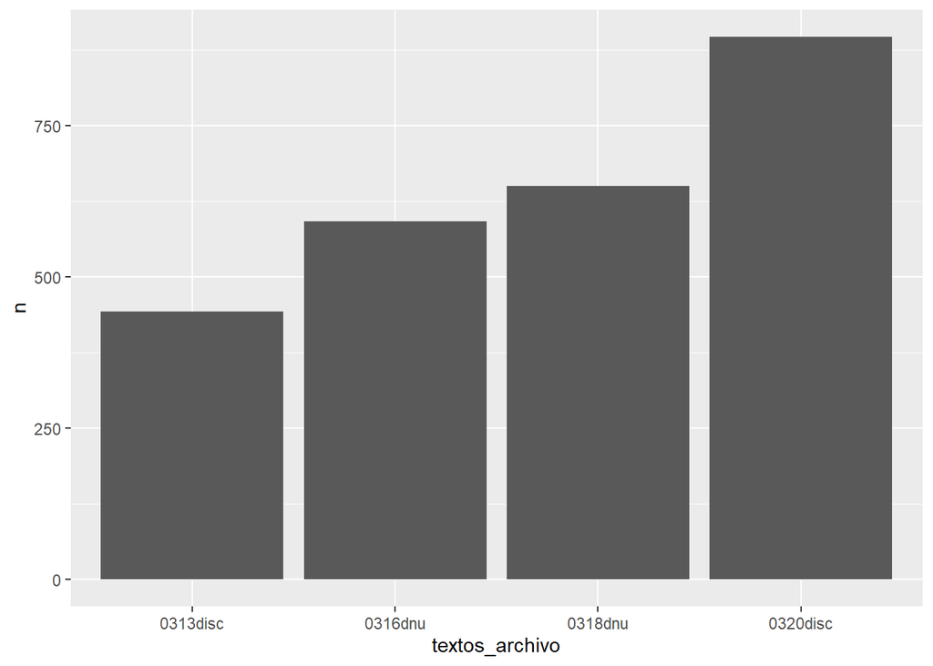

```r
mensajes_pal_limpio %>%
           group_by(textos_archivo) %>%
          count(palabra, sort = T) %>%
           ggplot() +
           geom_bar(aes(textos_archivo,
                        n),
                    stat = 'identity')
```

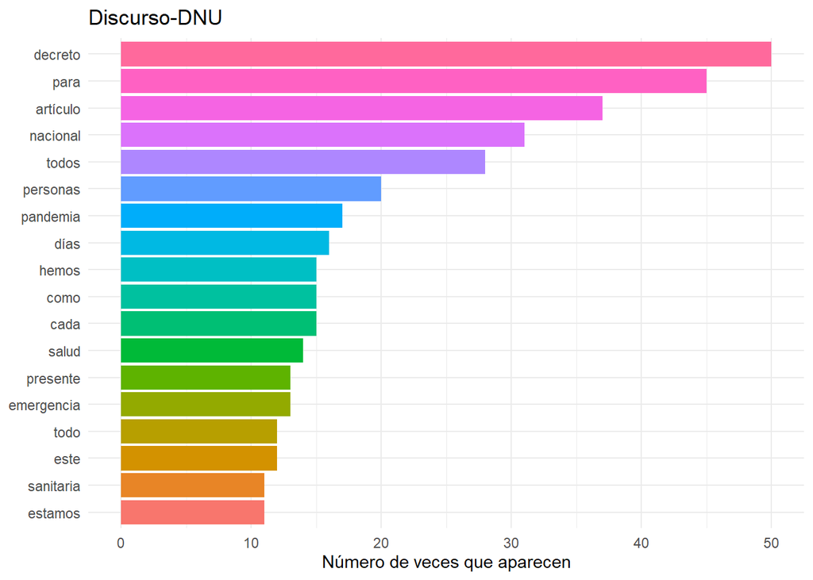

```r
mensajes_pal_limpio %>%
count(palabra, sort = T) %>%
filter(n > 10) %>%
mutate(palabra = reorder(palabra, n)) %>%
ggplot(aes(x = palabra, y = n, fill = palabra)) +
geom_bar(stat="identity") +
theme_minimal() +
theme(legend.position = "none") +
ylab("Número de veces que aparecen") +
xlab(NULL) +
ggtitle("Discurso-DNU") +
coord_flip()
```

Otra utilidad, que ha sido explicada en la parte teórica de la Unidad 2, es la Ley de Zipf, por lo cual, se reorganizaran los parámetros para poder apreciar la relación entre cada palabra y su frecuencia. Para ello, primero se armará una tabla con **mensajes_palabras**, con columnas con frecuencia absoluta = **n** y frecuencia relativa, sumada una última columna, se puede observar en la última línea, que indicará el orden de palabras en forma descendente, o el número de filas, llamada **Clasificacion**.

```r
mensajes_frecuencias <- mensajes_palabras %>%
  count (palabra, sort = TRUE) %>%
  mutate (relativa = n / sum(n)) %>%
   mutate(Clasificacion = row_number())

mensajes_frecuencias
```

```
## # A tibble: 1,343 x 4
##    palabra     n relativa Clasificacion
##    <chr>   <int>    <dbl>         <int>
##  1 de        343   0.0671             1
##  2 la        208   0.0407             2
##  3 que       191   0.0374             3
##  4 el        156   0.0305             4
##  5 a         147   0.0288             5
##  6 y         142   0.0278             6
##  7 en        129   0.0252             7
##  8 los        93   0.0182             8
##  9 del        72   0.0141             9
## 10 las        61   0.0119            10
## # ... with 1,333 more rows
```

Para realizar el gráfico con dichos datos, se utilizara la tabla con frecuencia relativa, clasificación y para la varianza de color la frecuencia absoluta. En la tercera línea, con el parámetro **geom_line** se modificará la línea que se grafica; y en las últimas dos, se indica que se debe usar en ambos ejes la escala logarítimica.

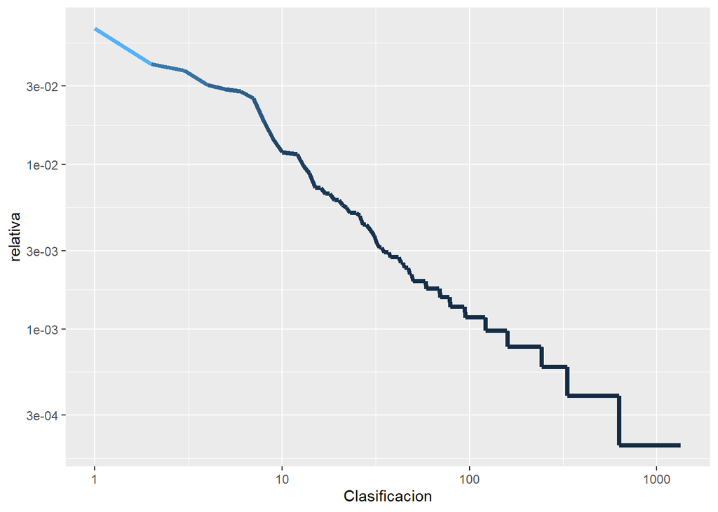

```r
mensajes_frecuencias %>%
  ggplot(aes(Clasificacion, relativa, color = n)) +
  geom_line(size = 1.5, alpha = 1.8, show.legend = FALSE) +
  scale_x_log10() +
  scale_y_log10()
```

Ahora, te propongo que realices los análisis y gráficos anteriores para los mensajes donde se han realizado la limpieza de palabras vacías y compares los resultados. Como ejercitación extra podrías intentar observar los cambios al considerar todos los archivos del corpus.

[^1]: Accesibles desde http://www.infoleg.gob.ar/?page_id=112 y https://www.casarosada.gob.ar/informacion/discursos?start=200.
[^2]: Para más información sobre ggplot2, véase Wilkinson, L., D. Wills, D. Rope, A. Norton, and R. Dubbs (2005. The Grammar of Graphics. Statistics and Computing. New York: Springer.
[^3]: Puedes acceder a más información de RegEx accediendo a https://es.wikipedia.org/wiki/Expresi%C3%B3n_regular.
[^4]: Puedes acceder a más información sobre **tibble** en https://cran.r-project.org/web/packages/tibble/vignettes/tibble.html.